# S371: Lab 3

# Histogram `hist()`

In R, histogram (and other graphs) would be displayed in the Plots window (default position: lower right-hand corner)

You can display the graph in a separate window by clicking Zoom:

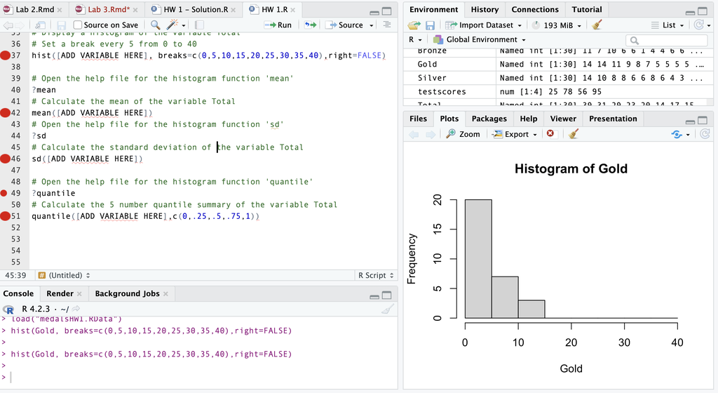

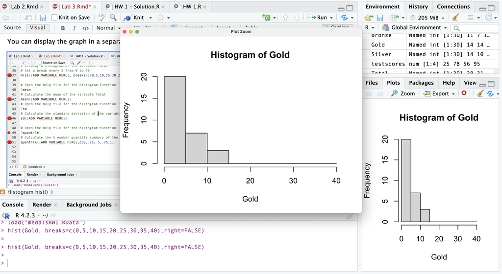

You can right-click the zoomed image and save it to your word document. You can also click “Export” button to do the same.

# `mean()` and `sd()` functions

You need to put down a variable within the parentheses.

- Other kinds of R objects are not allowed
- This function outputs the mean of the variable:

```r
mean(Gold)
```

```
## [1] 3.433333
```

- This function outputs the standard deviation of the variable

```r
sd(Gold)
```

```
## [1] 4.141325
```

`quantile()` - refer to the previous slides!

# HW1

- In the script file (HW 1.R), you also need to type three entire lines of code by yourself.
- Delete ## ADD CODE HERE ## with the appropriate R commands

# R script

Remember to modify the commands in the *R script file (HW 1.R)*, not do it directly in the R console.

At the end of the HW1 (Question 6 part e), you need to copy and paste the whole R script file with valid commands inside!

Don’t copy the R code and output from the console window

Just copy the content in the R script window

# Now let’s play with some data

```r
#make this example reproducible
set.seed(1)
n=300
#This command simulated data with the sample size n=300 with mean 50 and standard deviation of 10;
#distribution is normal.
mydata = rnorm(n, mean=50, sd=10)
#view first 6 observations in sample
head(mydata)
```

```
## [1] 43.73546 51.83643 41.64371 65.95281 53.29508 41.79532
```

```r
#As we asked R to do it, we have 300 observations in our data:
length(mydata)
```

```
## [1] 300
```

```r
#And we have mean of 50!
mean(mydata)
```

```
## [1] 50.33584
```

```r
#find standard deviation of sample
sd(mydata)
```

```
## [1] 9.636959
```

```r
# Calculate the 5 number quantile summary of the variable
quantile(mydata,c(0,.25,.5,.75,1))
```

```
##       0%      25%      50%      75%     100%
## 21.11079 44.10949 49.61563 56.72734 76.49167
```

# Let’s visualize the data!

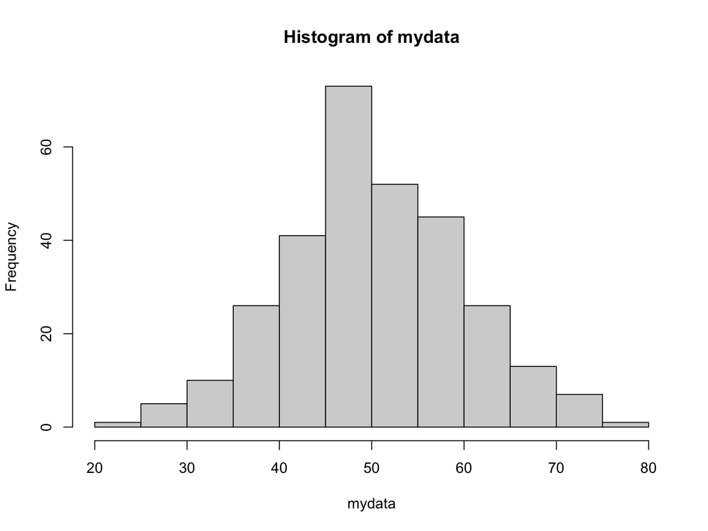

```r
hist(mydata, breaks=10,right=FALSE)
```

```r
?hist
```

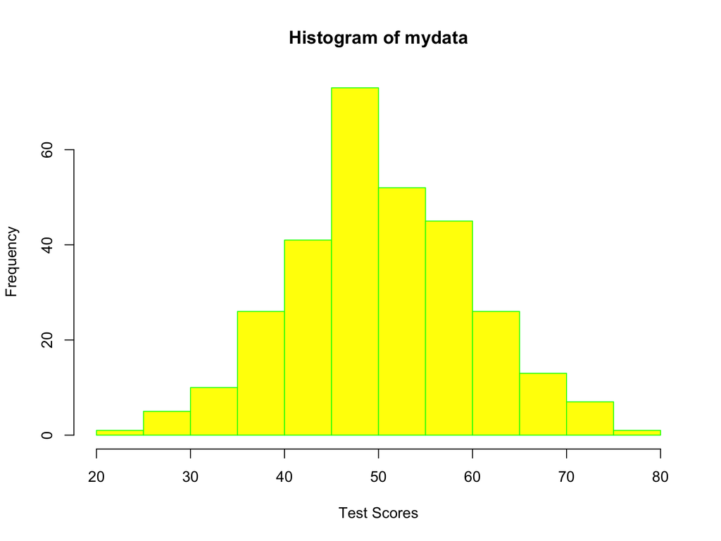

```r
hist(mydata, breaks=10,right=FALSE, xlab = "Test Scores", col = "yellow", border = "green")
```